# Second Degree Equations Part 3

## Graphing a Parabola Continued

Given a parabola $$y = ax^2 + bx + c$$ we can find three things.

First, we can find $x_+$ and $x_-$ such that $ax^2 + bx + c = 0$ with $$x_+, x_- = \frac{-b \pm \sqrt{b^2 - 4ac}}{2a}$$

Then, we can find the vertex of the parabola with $$\left(x_{vertex}, y_{vertex}\right) = \left(\frac{-b}{2a}, \frac{-\left(b^2 - 4ac\right)}{4a}\right)$$

## Graphing a Parabola Continued

The most straigt-forward way to graph a parabola is to plot a couple of points on it, and then connect them.

Let's try to graph $y = x^2 - 4$

First we can calculate and graph $$x_+, x_- = 2, -2$$

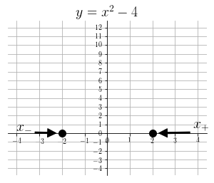

```python
#hideme

def f(x):
    return x**2 - 4

fig = plt.figure(figsize=(5, 4))
ax = fig.add_subplot(111)
ax.set_title("$y = x^2 - 4$", fontsize=20)

x = np.array([-2, 2])
y = f(x)
ax.plot(x, y, marker='o', markersize=10, linewidth=0, color="black")


xp = np.arange(-4, 4, 0.001)
yp = f(xp)
ax.plot(xp, yp, alpha=0)
ax.yaxis.set_major_locator(ticker.MultipleLocator(1))

ax.annotate('$x_+$', xy=(2.2, 0), xytext=(3.8, .4), size=20,
            arrowprops=dict(facecolor='black', shrink=0.05, width=2),
            )

ax.annotate('$x_-$', xy=(-2.2, 0), xytext=(-4, .4), size=20,
            arrowprops=dict(facecolor='black', shrink=0.05, width=2),
            )

ax.grid(True)

ax.spines['left'].set_position('zero')
ax.spines['right'].set_color('none')
ax.spines['bottom'].set_position('zero')
ax.spines['top'].set_color('none')
ax.xaxis.set_ticks_position('bottom')
ax.yaxis.set_ticks_position('left')
```

## Graphing a Parabola Continued

$$y = x^2 - 4$$

Now let's calclate the vertex

\begin{align} \left(x_{vertex}, y_{vertex}\right) &= \left(\frac{-b}{2a}, \frac{-\left(b^2 - 4ac\right)}{4a}\right) \\ &= \left(\frac{0}{2}, \frac{-\left(0 - 4(1)(-4)\right)}{4}\right) \\ &= \left(0, \frac{-\left(16\right)}{4}\right) = \left(0, -4\right) \end{align}

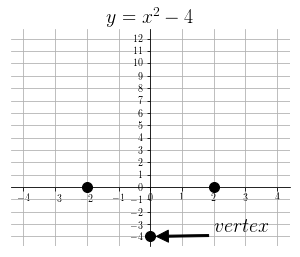

```python
#hideme

def f(x):
    return x**2 - 4

fig = plt.figure(figsize=(5, 4))
ax = fig.add_subplot(111)
ax.set_title("$y = x^2 - 4$", fontsize=20)

x = np.array([0, 2, -2])
y = f(x)
ax.plot(x, y, marker='o', linewidth=0, markersize=10, color="black")


xp = np.arange(-4, 4, 0.001)
yp = f(xp)
ax.plot(xp, yp, alpha=0)
ax.yaxis.set_major_locator(ticker.MultipleLocator(1))

ax.annotate('$vertex$', xy=(0.1, -4), xytext=(2, -3.6), size=20,
            arrowprops=dict(facecolor='black', shrink=0.05, width=2),
            )

ax.grid(True)

ax.spines['left'].set_position('zero')
ax.spines['right'].set_color('none')
ax.spines['bottom'].set_position('zero')
ax.spines['top'].set_color('none')
ax.xaxis.set_ticks_position('bottom')
ax.yaxis.set_ticks_position('left')
```

We need to calculate some additional points to the *left* and *right* of the vertex!

## Graphing a Parabola Continued

\begin{equation} y = x^2 - 4 \end{equation}

Let's make a chart to record our points. We'll start with the vertex at the center.

| $x$ | $y$ |
| --- | --- |
| -- | -- |
| -2 | 0 |
| -- | -- |
| 0 | -4 |
| -- | -- |
| 2 | 0 |
| -- | -- |

## Graphing a Parabola Continued

\begin{equation} y = x^2 - 4 \end{equation}

Now we can compute $x = -1$

\begin{equation} (-1)^2 - 4 = -3 \end{equation}

| $x$ | $y$ |
| --- | --- |
| -- | -- |
| -2 | 0 |
| -1 | -3 |
| 0 | -4 |
| -- | -- |
| 2 | 0 |
| -- | -- |

## Graphing a Parabola Continued

\begin{equation} y = x^2 - 4 \end{equation}

Now let's compute $x=1$

\begin{equation} (1)^2 - 4 = -3 \end{equation}

| $x$ | $y$ |
| --- | --- |
| -- | -- |
| -2 | 0 |
| -1 | -3 |
| 0 | -4 |
| 1 | -3 |
| 2 | 0 |
| -- | -- |

## Graphing a Parabola Continued

\begin{equation} y = x^2 - 4 \end{equation}

Lastly let's do $x=-3$, and $x=3$

\begin{align} (-3)^2 - 4 = 5 && (3)^2 - 4 = 5 \end{align}

| $x$ | $y$ |
| --- | --- |
| -3 | 5 |
| -2 | 0 |
| -1 | -3 |
| 0 | -4 |
| 1 | -3 |
| 2 | 0 |
| 3 | 5 |

## Plotting the points

With this chart, let's plot the points we found!

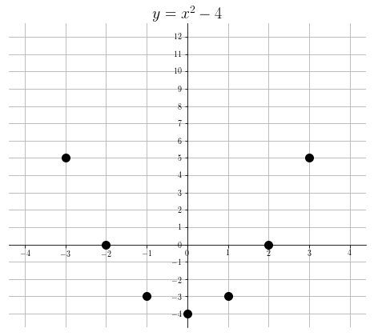

```python
#hideme

def f(x):
    return x**2 - 4

fig = plt.figure(figsize=(8, 7))
ax = fig.add_subplot(111)
ax.set_title("$y = x^2 - 4$", fontsize=20)

x = np.array([-3, -2, -1, 0, 1, 2, 3])
y = f(x)
ax.plot(x, y, marker='o', linewidth=0, markersize=10, color="black")


xp = np.arange(-4, 4, 0.001)
yp = f(xp)
ax.plot(xp, yp, alpha=0)
ax.yaxis.set_major_locator(ticker.MultipleLocator(1))

ax.grid(True)

ax.spines['left'].set_position('zero')
ax.spines['right'].set_color('none')
ax.spines['bottom'].set_position('zero')
ax.spines['top'].set_color('none')
ax.xaxis.set_ticks_position('bottom')
ax.yaxis.set_ticks_position('left')
```

All that's left to do now is draw in the line!

## Plotting the points

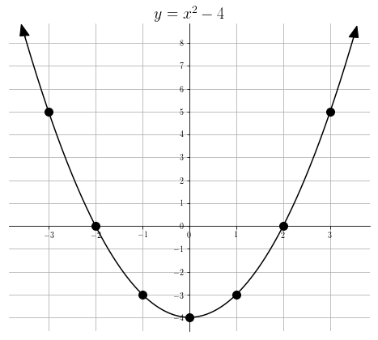

```python
#hideme

def f(x):
    return x**2 - 4


def makeArrow(ax,pos,function,direction):
    delta = 0.0001 if direction >= 0 else -0.01
    ax.arrow(pos,function(pos),delta,function(pos+delta)-function(pos),head_width=0.2,head_length=0.5, color="black")


fig = plt.figure(figsize=(8, 7))
ax = fig.add_subplot(111)
ax.set_title("$y = x^2 - 4$", fontsize=20)

x = np.array([-3, -2, -1, 0, 1, 2, 3])
y = f(x)
ax.plot(x, y, marker='o', linewidth=0, markersize=10, color="black")

xleft = np.arange(-3.5, 0, 0.001)
yleft = f(xleft)

makeArrow(ax, -3.5, f, -1)
makeArrow(ax, 3.5, f, 1)

xp = np.arange(-3.5, 3.5, 0.001)
yp = f(xp)
ax.plot(xp, yp, color="black")
ax.yaxis.set_major_locator(ticker.MultipleLocator(1))
ax.grid(True)


ax.spines['left'].set_position('zero')
ax.spines['right'].set_color('none')
ax.spines['bottom'].set_position('zero')
ax.spines['top'].set_color('none')
ax.xaxis.set_ticks_position('bottom')
ax.yaxis.set_ticks_position('left')
```

True or False: we only have to compute values on one side of the vertex

True! The parabola is symmetric about $x_{vertex}$, so the value for $x_{vertex} - k$ is the same value for $x_{vertex} + k$.

## Trivia Question

True or False: we should **always** graph $x_+$ and $x_-$

False! If $x_+$ and $x_-$ are not rational numers, we shouldn't really try to plot them.

For example, if $$x_+, x_- = \frac{3 \pm \sqrt{12}}{6}$$ we shouldn't bother plotting the points.

## Let's practice!

In *groups of 3* graph the following parabolas using the method we've just seen

\begin{align} x^2+2x-3 \\ x^2-4x+2 \\ -2x^2-4x+2 \end{align}

## Problem 1

$$y = x^2+2x-3$$\begin{equation} x_+, x_- = \frac{-b \pm \sqrt{b^2 - 4ac}}{2a} = \frac{-2 \pm \sqrt{4 + 12}}{2} = \frac{-2 \pm 4}{2} = 1, -3 \end{equation}\begin{equation} \left(x_{vertex}, y_{vertex}\right) = \left(\frac{-b}{2a}, \frac{-\left(b^2 - 4ac\right)}{4a}\right) = \left(\frac{-2}{2}, \frac{-\left(4 + 12\right)}{4}\right) = \left(-1, -4\right) \end{equation}

| $x$ | -4 | -3 | -2 | -1 | 0 | 1 | 2 |
| --- | --- | --- | --- | --- | --- | --- | --- |
| $y$ | 5 | 0 | -3 | -4 | -3 | 0 | 5 |

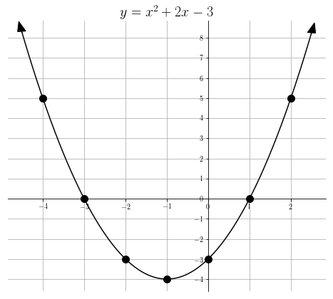

```python
#hideme

def f(x):
    return x**2 + 2*x - 3


def makeArrow(ax,pos,function,direction):
    delta = 0.0001 if direction >= 0 else -0.01
    ax.arrow(pos,function(pos),delta,function(pos+delta)-function(pos),head_width=0.2,head_length=0.5, color="black")


fig = plt.figure(figsize=(8, 7))
ax = fig.add_subplot(111)
ax.set_title("$y = x^2 +2x - 3$", fontsize=20)

x = np.array([-4, -3, -2, -1, 0, 1, 2])
y = f(x)
ax.plot(x, y, marker='o', linewidth=0, markersize=10, color="black")

xleft = np.arange(-3.5, 0, 0.001)
yleft = f(xleft)

makeArrow(ax, -4.5, f, -1)
makeArrow(ax, 2.5, f, 1)

xp = np.arange(-4.5, 2.5, 0.001)
yp = f(xp)
ax.plot(xp, yp, color="black")
ax.yaxis.set_major_locator(ticker.MultipleLocator(1))
ax.grid(True)


ax.spines['left'].set_position('zero')
ax.spines['right'].set_color('none')
ax.spines['bottom'].set_position('zero')
ax.spines['top'].set_color('none')
ax.xaxis.set_ticks_position('bottom')
ax.yaxis.set_ticks_position('left')
```

## Problem 2

$$y=x^2-4x+2$$\begin{equation} x_+, x_- = \frac{-b \pm \sqrt{b^2 - 4ac}}{2a} = \frac{4 \pm \sqrt{16 - 8}}{2} = \frac{4 \pm \sqrt{8}}{2}= \text{not nice} \end{equation}\begin{equation} \left(x_{vertex}, y_{vertex}\right) = \left(\frac{-b}{2a}, \frac{-\left(b^2 - 4ac\right)}{4a}\right) = \left(\frac{4}{2}, \frac{-\left(16 - 8\right)}{4}\right) = \left(2, -2\right) \end{equation}

| $x$ | -1 | 0 | 1 | 2 | 3 | 4 | 5 |
| --- | --- | --- | --- | --- | --- | --- | --- |
| $y$ | 7 | 2 | -1 | -2 | -1 | 2 | 7 |

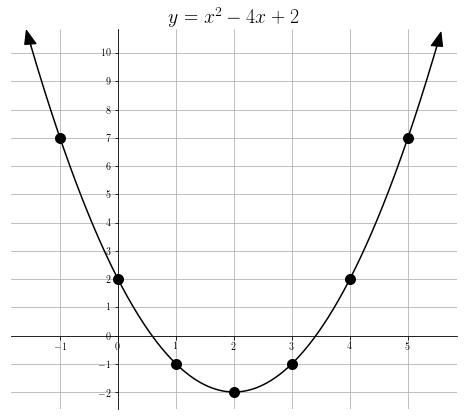

```python
#hideme

def f(x):
    return x**2 - 4*x + 2


def makeArrow(ax,pos,function,direction):
    delta = 0.0001 if direction >= 0 else -0.01
    ax.arrow(pos,function(pos),delta,function(pos+delta)-function(pos),head_width=0.2,head_length=0.5, color="black")


fig = plt.figure(figsize=(8, 7))
ax = fig.add_subplot(111)
ax.set_title("$y = x^2 - 4x + 2$", fontsize=20)

x = np.array([-1, 0, 1, 2, 3, 4, 5])
y = f(x)
ax.plot(x, y, marker='o', linewidth=0, markersize=10, color="black")



makeArrow(ax, -1.5, f, -1)
makeArrow(ax, 5.5, f, 1)

xp = np.arange(-1.5, 5.5, 0.001)
yp = f(xp)
ax.plot(xp, yp, color="black")
ax.yaxis.set_major_locator(ticker.MultipleLocator(1))
ax.grid(True)


ax.spines['left'].set_position('zero')
ax.spines['right'].set_color('none')
ax.spines['bottom'].set_position('zero')
ax.spines['top'].set_color('none')
ax.xaxis.set_ticks_position('bottom')
ax.yaxis.set_ticks_position('left')
```

## Problem 3

$$y = -2x^2-4x+2$$\begin{equation} x_+, x_- = \frac{-b \pm \sqrt{b^2 - 4ac}}{2a} = \frac{4 \pm \sqrt{16 + 16}}{-4} = \frac{4 \pm \sqrt{32}}{-4}= \text{not nice} \end{equation}\begin{equation} \left(x_{vertex}, y_{vertex}\right) = \left(\frac{-b}{2a}, \frac{-\left(b^2 - 4ac\right)}{4a}\right) = \left(\frac{4}{-4}, \frac{-\left(16 + 16\right)}{-8}\right) = \left(-1, 4\right) \end{equation}

| $x$ | -4 | -3 | -2 | -1 | 0 | 1 | 2 |
| --- | --- | --- | --- | --- | --- | --- | --- |
| $y$ | -14 | -4 | 2 | 4 | 2 | -4 | -14 |

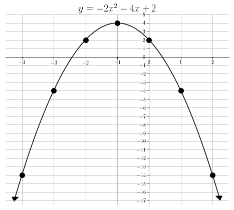

```python
#hideme

def f(x):
    return -2*x**2 - 4*x + 2


def makeArrow(ax,pos,function,direction):
    delta = 0.0001 if direction >= 0 else -0.01
    ax.arrow(pos,function(pos),delta,function(pos+delta)-function(pos),head_width=0.2,head_length=0.5, color="black")


fig = plt.figure(figsize=(8, 7))
ax = fig.add_subplot(111)
ax.set_title("$y = -2x^2 - 4x + 2$", fontsize=20)

x = np.array([-4, -3, -2, -1, 0, 1, 2])
y = f(x)
ax.plot(x, y, marker='o', linewidth=0, markersize=10, color="black")



makeArrow(ax, -4.2, f, -1)
makeArrow(ax, 2.2, f, 1)

xp = np.arange(-4.2, 2.2, 0.001)
yp = f(xp)
ax.plot(xp, yp, color="black")
ax.yaxis.set_major_locator(ticker.MultipleLocator(1))
ax.grid(True)


ax.spines['left'].set_position('zero')
ax.spines['right'].set_color('none')
ax.spines['bottom'].set_position('zero')
ax.spines['top'].set_color('none')
ax.xaxis.set_ticks_position('bottom')
ax.yaxis.set_ticks_position('left')
```

## Vertex Form of a Parabola

We have been working with parabolas with equations that look like

\begin{equation} y = ax^2 + bx + c \end{equation}

But there is a way to re-arrange our terms to get our expression into *vertex form*.

Given a parabola, we can find

\begin{equation} (x_{vertex}, y_{vertex}) = (h, k) \end{equation}

We can then write our parabola as

\begin{equation} y = a(x-h)^2 + k \end{equation}

This makes the symmetry of the parabola easy to see!

## Vertex Form of a Parabola

True or False: The *vertex form* of a quadratic expression is easier to work with.

True! We don't have to calculate the vertex, only read it. Calculating points is also easier!

## Vertex Form of a Parabola - Practice

\begin{equation} (x_{vertex}, y_{vertex}) = (h, k) \end{equation}\begin{equation} y = a(x-h)^2 + k \end{equation}

What is the vertex for each of the following parabolas?

\begin{align} (x-2)^2 + 4 \\ 5(x+5)^2 - 10 \\ -2(x-12)^2 + 6 \end{align}

## Vertex Form of a Parabola - Practice

What is the vertex for each of the following parabolas?

\begin{align} (x-2)^2 + 4 &\ \rightarrow \ (2, 4)\\ 5(x+5)^2 - 10 &\\ -2(x-12)^2 + 6 & \end{align}

## Vertex Form of a Parabola - Practice

What is the vertex for each of the following parabolas?

\begin{align} (x-2)^2 + 4 &\ \rightarrow \ (2, 4)\\ 5(x+5)^2 - 10 &\ \rightarrow \ (-5, -10) \\ -2(x-12)^2 + 6 & \end{align}

## Vertex Form of a Parabola - Practice

What is the vertex for each of the following parabolas?

\begin{align} (x-2)^2 + 4 &\ \rightarrow \ (2, 4)\\ 5(x+5)^2 - 10 &\ \rightarrow \ (-5, -10) \\ -2(x-12)^2 + 6 &\ \rightarrow \ (12, 6) \end{align}

## Practice!

Spend the last few minutes graphing the equation

$$y = (x-2)^2 - 2$$

| $x$ | -1 | 0 | 1 | 2 | 3 | 4 | 5 |
| --- | --- | --- | --- | --- | --- | --- | --- |
| $y$ | 7 | 2 | -1 | -2 | -1 | 2 | 7 |

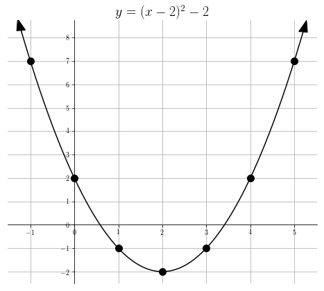

```python
#hideme

def f(x):
    return (x-2)**2 - 2


def makeArrow(ax,pos,function,direction):
    delta = 0.0001 if direction >= 0 else -0.01
    ax.arrow(pos,function(pos),delta,function(pos+delta)-function(pos),head_width=0.2,head_length=0.5, color="black")


fig = plt.figure(figsize=(8, 7))
ax = fig.add_subplot(111)
ax.set_title("$y = (x-2)^2 - 2$", fontsize=20)

x = np.array([-1, 0, 1, 2, 3, 4, 5])
y = f(x)
ax.plot(x, y, marker='o', linewidth=0, markersize=10, color="black")



makeArrow(ax, -1.2, f, -1)
makeArrow(ax, 5.2, f, 1)

xp = np.arange(-1.2, 5.2, 0.001)
yp = f(xp)
ax.plot(xp, yp, color="black")
ax.yaxis.set_major_locator(ticker.MultipleLocator(1))
ax.grid(True)


ax.spines['left'].set_position('zero')
ax.spines['right'].set_color('none')
ax.spines['bottom'].set_position('zero')
ax.spines['top'].set_color('none')
ax.xaxis.set_ticks_position('bottom')
ax.yaxis.set_ticks_position('left')
```

## Wrapping up

Today we learned how to graph parabolas by calculating points.

Next time we will learn how to use our knowledge to solve real world problems!